# Information Based Machine Learning (Part 2)

This is the second part of a set of notes explaining how we can implement the ID3 decision tree learning algorithm using entropy based information gain in Python.

The first part of these notes explained how to **Implementing the ID3 Algorithm in Python**. In this section of the notes we explain how to use **the sci-kit API** to get data and create models. this section provide example code that illustrates how to use the **pandas** API to read in data from a file and how to use the **sci-kit** machine learning API to create, use and evaluate decision tree models.

In order to run the code in these notes you will need to have Python 3.x, Pandas and sci-kit installed on your machine.

## Using APIs to Get Data and Create Models

The dataset we will use to demonstrate how we can read in data from files and create prediction models is a version of Census Income dataset (same dataset you've been using for your Assignment) which is available from the UCI Machine Learning Repository at:

https://archive.ics.uci.edu/ml/datasets/Census+Income

### Reading Data from a File with **pandas**

The Python code below shows how we can use the **pandas** API **read_csv()** function to load the data from a file in an online repository or from a local .csv file and to display the first few rows of the datset.

The panda's **read_csv()** function returns the data in a **DataFrame** object. A DataFrame is a tabular datastructure with rows and columns. By default, each column in a DataFrame has a name and each row in a DateFrame has an index. It is very easy to extract particular columns and rows from a DataFrame using the column name or index.

By default the **read_csv()** funciton will use the first column in the file as the index for the rows in the DataFrame. By setting **index_col=False** equal to false we override this behavior and the index of each row in the frame is simply the line number (indexed from 0) of the row in the file.

By default the **read_csv()** function will try to infer the headings for the columns by looking at the first row in a file. In this example, however, when we read the file from the URL we have told the **read_csv()** function not to treat the first row of the file as listing the column headings; we did this by setting the parameter **header=None**. We also tell the function the column names we want to use by passing in the list of column names to the **names** parameter: **names=columnHeadings**. Note that when we write the file back out to a local csv file we include the column headings in the file; that is why when we read the file from the local csv file we allow the **read_csv()** function to carry out the default behavior of interpreting the first line of the file as a list of column headings.

Notice that when we output the first five rows of the data it is in table form with column headings included and row indexs starting from 0. The target feature for this dataset is the **annualincome** feature on the right of the table.

```python
import pandas as pd

fromUrl = False


if (fromUrl):
    #Reading the dataset from an online repository:
    #-----------------------------------------------
    fileUrl = 'https://archive.ics.uci.edu/ml/machine-learning-databases/adult/adult.data'
    #define the list of column headings for the dataset. This list is based on the documentation
    #for the dataset available at:
    #https://archive.ics.uci.edu/ml/machine-learning-databases/adult/adult.names
    columnHeadings=['age','workclass','fnlwgt','education','education-num','marital-status','occupation','relationship','race','sex','capital-gain','capital-loss','hours-per-week','native-country','annualincome']
    # we can directly use read_csv to download the file
    censusData = pd.read_csv(fileUrl,header=None,names=columnHeadings,index_col=False,na_values=['?'],nrows=32560)
    # save the file locally
    censusData.to_csv('../Datasets/censusDataRaw.csv',index=False)
else:
    #Reading the dataset from a local file
    #---------------------------------------------
    censusData = pd.read_csv("../Datasets/censusDataRaw.csv",index_col=False,na_values=['?'],nrows=32560)

# lets have a look at the top of the dataset
censusData.head()
```

|  | age | workclass | fnlwgt | education | education-num | marital-status | occupation | relationship | race | sex | capital-gain | capital-loss | hours-per-week | native-country | annualincome |
| --- | --- | --- | --- | --- | --- | --- | --- | --- | --- | --- | --- | --- | --- | --- | --- |
| 0 | 39 | State-gov | 77516 | Bachelors | 13 | Never-married | Adm-clerical | Not-in-family | White | Male | 2174 | 0 | 40 | United-States | <=50K |
| 1 | 50 | Self-emp-not-inc | 83311 | Bachelors | 13 | Married-civ-spouse | Exec-managerial | Husband | White | Male | 0 | 0 | 13 | United-States | <=50K |
| 2 | 38 | Private | 215646 | HS-grad | 9 | Divorced | Handlers-cleaners | Not-in-family | White | Male | 0 | 0 | 40 | United-States | <=50K |
| 3 | 53 | Private | 234721 | 11th | 7 | Married-civ-spouse | Handlers-cleaners | Husband | Black | Male | 0 | 0 | 40 | United-States | <=50K |
| 4 | 28 | Private | 338409 | Bachelors | 13 | Married-civ-spouse | Prof-specialty | Wife | Black | Female | 0 | 0 | 40 | Cuba | <=50K |

# sci-kit API

sci-kit is a Python machine learning library. More information on sci-kit is available at:

http://scikit-learn.org/stable/

To use the sci-kit API we need to import the **sklearn** library.

One thing to be aware of when using sci-kit is that the model building functions expects the training data in a particular format. In particular: 1. All the descriptive feature values should be numeric (i.e., sci-kit API functions won't accept categorical features) so if we want to use categorical features we need to **map** them to numbers before we pass the dataset into the sci-kit training and prediction functions. 2. The descriptive features and target feature should be passed in as two different variables.

The code below illustrates how we use the **DictVectorizer** class from the **sci-kit** API to convert categorical feature values into numeric representations.

The **DictVectorizer** class is described in more detail at:

http://scikit-learn.org/stable/modules/generated/sklearn.feature_extraction.DictVectorizer.html

However, the main thing you need to understand about how it works is that when feature values are strings, this class will map the strings to binary one-hot coding. This means that there will be one boolean valued feature for each of the possible strings values in the domain of a feature. For example, if there is a feature F1 that can take three values 'low', 'medium', and 'high' then this feature will be mapped to 3 binary features. So, for example F1='low' will be encoded as '1, 0, 0'; F1='medium' will be encoded as '0, 1, 0'; and F1='high will be encoded as '0, 0, 1'.

### Example Illustrating one-hot encoding

```python
#This code illustrates how the DictVectorizer class works.

from sklearn.feature_extraction import DictVectorizer
#create the vectorizor object
v = DictVectorizer(sparse=False)
#create some sample data listing the different values in the domain of 3 features 'foo', 'bar, 'baz'
D = [{'foo': 'f1v1', 'bar': 'f2v1'}, {'foo': 'f1v2', 'baz': 'f3v1'}, {'foo': 'f1v3', 'bar': 'f2v2'}, {'foo': 'f1v2', 'baz': 'f3v2'}]
#pass in the data into the vectorizer object so that it can learn an encoding for the feature values, this function
#also returns the data after the encoding as been applied (but we will ignore this for now)
X=v.fit_transform(D)
#Now we will output the mapping from feature values to binary features:
print("Mapping from feature values to binary features:")
enc_dict = v.vocabulary_
for k in sorted(enc_dict.keys()):
    mapping = k + " : column " + str(enc_dict[k]) + " = 1"
    print(mapping)

#The following examples show how we can use the vectorizer object to encode other vectors using the same encoding:
print("Encode other feature vectors using the above one-hot encoding:")
data_2_vectorize = {'foo': 'f1v1', 'bar': 'f2v1', 'baz': 'f3v1'}
vectorized_data = v.transform(data_2_vectorize)
print(vectorized_data[0])
data_2_vectorize2 = {'foo': 'f1v2', 'bar': 'f2v2', 'baz': 'f3v2'}
vectorized_data = v.transform(data_2_vectorize2)
print(vectorized_data[0])
data_2_vectorize3 = {'foo': 'f1v1', 'bar': 'f2v2', 'baz': 'f3v1'}
vectorized_data = v.transform(data_2_vectorize3)
print(vectorized_data[0])
```

```
Mapping from feature values to binary features:
bar=f2v1 : column 0 = 1
bar=f2v2 : column 1 = 1
baz=f3v1 : column 2 = 1
baz=f3v2 : column 3 = 1
foo=f1v1 : column 4 = 1
foo=f1v2 : column 5 = 1
foo=f1v3 : column 6 = 1
Encode other feature vectors using the above one-hot encoding:
[ 1.  0.  1.  0.  1.  0.  0.]
[ 0.  1.  0.  1.  0.  1.  0.]
[ 0.  1.  1.  0.  1.  0.  0.]
```

### Preprocessing and Cleaning the Data

The code below does some preprocessing on the training data:

1. it separates the target feature and descriptive features into two different data strutures; this is very easy to do because the data is in a DataFrame and we can extract the target feature by simply requesting the column in the dataframe that has the name 'annualincome'. Selecting a single column from a DataFrame returns a **Series** object. A Series is a 1-Dimensional array/list like object. Every element of the series has a index. By default, each element will recieve an index from 0 to N-1, where N is the number of elements in the Series. We can extract an element from a series using the index. In the example code we print the first, second and fifth element in the targetLabels series.
2. it extracts the numeric descriptive features into a new DataFrame; again, the fact that the data is in a DataFrame object makes this very easy to do, we simply define a list containing the names of the numeric features and retrieve these columns from the DataFrame. Extracting multiple columns from a DataFrame returns another DataFrame object.
3. it extracts the categorical features into a new DataFrame. We do this using the DataFrame **drop()** function. The **drop()** function returns a new object with the request columns/rows removed. In this case we wish to remove the numeric and target columns so we list the names of these columns and set axis=1 (see the following StackOverflow discussion on how to understand axis terminology in Pandas: http://stackoverflow.com/questions/25773245/ambiguity-in-pandas-dataframe-axis-definition )
4. it uses a *DictVectorizor* object to apply one-hot encoding to the categorical features. The line **cat_dfs = cat_dfs.T.to_dict().values()** is worth discussing. The **T** operator transposes the columns and indexes in a DataFrame (so each columns becomes a row. The DataFrame **to_dict()** function makes a dictionary for every column in the DataFrame where the keys in each dictionary are the row indexes. Because we have transposed the rows and columns in the DataFrame this means that we end up with a dictionary for every row in the dataset (now a column in the transposed DataFrame) and the keys in each dictionary are the descriptive feature names. Finally, applying the **values()** function means that for each dictionary we get a list containing the values in the dictionary. In other words, we end up with a list for each instance in the dataset that contains the feature values for that instance. We then pass this lists of feature values in the DictVectorizer to apply the one-hot encoding to them.
5. it merges the numerics and one-hot encoded categorical features back together using the **Numpy** **hstack()** function. (Note **Numpy** is the Python library that pandas and sci-kit are built on top of.)

```python
from pandas import DataFrame
from sklearn import preprocessing
from sklearn.feature_extraction import DictVectorizer
import numpy as np

####################################
# Extract Target Feature
###################################
# **sci-kit** expects that the descriptive features and target features
# are passed to the model training functions as separate parameters.
# so the first step in data preprocessins is to extract the
# target feature values into a separate variable
targetLabels = censusData['annualincome']
print("Sample target labels!:")
print(targetLabels[0])
print(targetLabels[1])
print(targetLabels[4])

####################################
# Extract Numeric Descriptive Features
###################################
# We want to do some preprocessing on the categorical data so
# We first extract the numeric_features into a separate data structure
numeric_features = ['age','fnlwgt','education-num','capital-gain','capital-loss','hours-per-week']
numeric_dfs = censusData[numeric_features]
print("-------------------------")
print("Sample numeric features!:")
numeric_dfs.head()

####################################
# Extract Categorical Descriptive Features
###################################
cat_dfs = censusData.drop(numeric_features + ['annualincome'],axis=1)
print("-------------------------")
print("Raw Cat features:")
print(cat_dfs.head())

####################################
# Remove missing values and apply one-hot encoding
###################################
#handle missing values
#If the data has missing values, they will become NaNs in the Numpy arrays generated by the vectorizor so lets get rid of them
cat_dfs.replace('?','NA')
cat_dfs.fillna( 'NA', inplace = True )

#transpose into array of dictionaries (one dict per instance) of feature:level pairs
cat_dfs = cat_dfs.T.to_dict().values()
#convert to numeric encoding
vectorizer = DictVectorizer( sparse = False )
vec_cat_dfs = vectorizer.fit_transform(cat_dfs)
print("-------------------------")
print("Output the numeric encoding mapping:")
encoding_dictionary = vectorizer.vocabulary_
for k in sorted(encoding_dictionary.keys()):
    mapping = k + " : column " + str(encoding_dictionary[k]) + " = 1"
    print(mapping)

print("-------------------------")
print("Processed Cat features for first 5 instances:")
print(vec_cat_dfs[0])
print(vec_cat_dfs[1])
print(vec_cat_dfs[2])
print(vec_cat_dfs[3])
print(vec_cat_dfs[4])


########################################################
# Merge Categorical and Numeric Descriptive Features
########################################################
train_dfs = np.hstack((numeric_dfs.as_matrix(), vec_cat_dfs ))
```

```
Sample target labels!:
 <=50K
 <=50K
 <=50K
-------------------------
Sample numeric features!:
-------------------------
Raw Cat features:
           workclass   education       marital-status          occupation  \
0          State-gov   Bachelors        Never-married        Adm-clerical
1   Self-emp-not-inc   Bachelors   Married-civ-spouse     Exec-managerial
2            Private     HS-grad             Divorced   Handlers-cleaners
3            Private        11th   Married-civ-spouse   Handlers-cleaners
4            Private   Bachelors   Married-civ-spouse      Prof-specialty

     relationship    race      sex  native-country
0   Not-in-family   White     Male   United-States
1         Husband   White     Male   United-States
2   Not-in-family   White     Male   United-States
3         Husband   Black     Male   United-States
4            Wife   Black   Female            Cuba
-------------------------
Output the numeric encoding mapping:
education= 10th : column 0 = 1
education= 11th : column 1 = 1
education= 12th : column 2 = 1
education= 1st-4th : column 3 = 1
education= 5th-6th : column 4 = 1
education= 7th-8th : column 5 = 1
education= 9th : column 6 = 1
education= Assoc-acdm : column 7 = 1
education= Assoc-voc : column 8 = 1
education= Bachelors : column 9 = 1
education= Doctorate : column 10 = 1
education= HS-grad : column 11 = 1
education= Masters : column 12 = 1
education= Preschool : column 13 = 1
education= Prof-school : column 14 = 1
education= Some-college : column 15 = 1
marital-status= Divorced : column 16 = 1
```

[output cut: 102 more lines]

```
  0.  0.  0.  0.  0.  0.  0.  0.  1.  0.  0.  0.  0.  0.  0.  0.  0.  1.
  0.  0.  0.  0.  0.  0.  0.  0.  0.  0.  0.  0.  1.  0.  1.  0.  0.  0.
  0.  0.  1.  0.  0.  0.  0.  1.  0.  0.  0.  0.]
[ 0.  1.  0.  0.  0.  0.  0.  0.  0.  0.  0.  0.  0.  0.  0.  0.  0.  0.
  1.  0.  0.  0.  0.  0.  0.  0.  0.  0.  0.  0.  0.  0.  0.  0.  0.  0.
  0.  0.  0.  0.  0.  0.  0.  0.  0.  0.  0.  0.  0.  0.  0.  0.  0.  0.
  0.  0.  0.  0.  0.  0.  0.  0.  1.  0.  0.  0.  0.  0.  0.  0.  0.  1.
  0.  0.  0.  0.  0.  0.  0.  0.  0.  0.  1.  0.  0.  1.  0.  0.  0.  0.
  0.  0.  1.  0.  0.  0.  0.  1.  0.  0.  0.  0.]
[ 0.  0.  0.  0.  0.  0.  0.  0.  0.  1.  0.  0.  0.  0.  0.  0.  0.  0.
  1.  0.  0.  0.  0.  0.  0.  0.  0.  0.  1.  0.  0.  0.  0.  0.  0.  0.
  0.  0.  0.  0.  0.  0.  0.  0.  0.  0.  0.  0.  0.  0.  0.  0.  0.  0.
  0.  0.  0.  0.  0.  0.  0.  0.  0.  0.  0.  0.  0.  0.  0.  0.  0.  0.
  0.  0.  0.  1.  0.  0.  0.  0.  0.  0.  1.  0.  0.  0.  0.  0.  0.  0.
  1.  1.  0.  0.  0.  0.  0.  1.  0.  0.  0.  0.]
```

### Creating Prediction Models Using *sci-kit*

The code example below uses the **sci-kit** API to create some decision tree models.

These models are trained using the data that was preprocssed above.

```python
from sklearn import tree
from sklearn import cross_validation

#---------------------------------------------------------------
#   Create and train a decision tree model using sklearn api
#---------------------------------------------------------------
print("Creating the decision tree model")
#create an instance of a decision tree model.
#documentation on the DecisionTreeClassifier constructor is available from:
#http://scikit-learn.org/stable/modules/generated/sklearn.tree.DecisionTreeClassifier.html
#In this instance we set the model parameters to use entropy based information gain,
decTreeModel = tree.DecisionTreeClassifier(criterion='entropy')
#fit the model using the numeric representations of the training data
decTreeModel.fit(train_dfs, targetLabels)

#---------------------------------------------------------------
#   Define Queries, Make Predictions, Map Predictions to Levels
#---------------------------------------------------------------
print("Defining queries, making predictions and mapping predictions to levels")
#To illustrate how to use the model to make predictions we will use the first 2 rows of the training dataset as queries.
#NOTE: Using the data you used to train a model as queries to test a model is a very bad idea!!!!!
#The only reason we do this hear is to illustrate how we would prepare the queries in order to input them into the model
#and how to convert the the predictions returned by the model bask to the original levels in the dataset.

#Notice that when we convert a query to a numeric representation we pass in the same mapping that was used to
#transform the descriptive features in the training datset.
#we start by defining the query as as dictionary (note, we store the value as list to help with the conversion to a dataframe object later)
q = {'age':[39,50],'workclass':['State-gov','Self-emp-not-inc'],'fnlwgt':[77516,83311],'education':['Bachelors','Bachelors'],'education-num':[13,13],'marital-status':['Never-married','Married-civ-spouse'],'occupation':['Adm-clerical','Exec-managerial'],'relationhip':['Not-in-family','Husband'],'race':['White','White'],'sex':['Male','Male'],'capital-gain':[2174,0],'capital-loss':[0,0],'hours-per-week':[40,13],'native_country':['United-States','United-States']}
col_names = ['age','workclass','fnlwgt','education','education-num','marital-status','occupation','relationhip','race','sex','capital-gain','capital-loss','hours-per-week','native_country']
qdf = pd.DataFrame.from_dict(q,orient="columns")
print("\n")
print("Raw Queries!")
print("------------------------------")
print(qdf)

q_num = qdf[numeric_features].as_matrix() #extract the numeric features

#convert the categorical features
q_cat = qdf.drop(numeric_features,axis=1)
q_cat_dfs = q_cat.T.to_dict().values()
q_vec_dfs = vectorizer.transform(q_cat_dfs)

query = np.hstack((q_num, q_vec_dfs ))
print("\n")
print("Preprocessed Queries")
print("------------------------------")
print(query[0])
print(query[1])

#Use the model to make predictions for the 2 queries
predictions = decTreeModel.predict([query[0],query[1]])

print("\n")
print("Predictions!")
print("------------------------------")
print(predictions)
#The predictions returned by the model are numeric so map them back to the levels in the dataset and output the predictions.
#Because we use the first 3 rows of the training data as the queries we would expect that the models predictions should
#match the first 3 entries in the annualIncome column (if everything is working correctly!
#predictedLevels = convertMapping2Level(predictions,targetMappings)
#print("Predicted Levels are: " + str(predictedLevels))
```

```
Creating the decision tree model
Defining queries, making predictions and mapping predictions to levels


Raw Queries!
------------------------------
   age  capital-gain  capital-loss  education  education-num  fnlwgt  \
0   39          2174             0  Bachelors             13   77516
1   50             0             0  Bachelors             13   83311

   hours-per-week      marital-status native_country       occupation   race  \
0              40       Never-married  United-States     Adm-clerical  White
1              13  Married-civ-spouse  United-States  Exec-managerial  White

     relationhip   sex         workclass
0  Not-in-family  Male         State-gov
1        Husband  Male  Self-emp-not-inc


Preprocessed Queries
------------------------------
[  3.90000000e+01   7.75160000e+04   1.30000000e+01   2.17400000e+03
   0.00000000e+00   4.00000000e+01   0.00000000e+00   0.00000000e+00
   0.00000000e+00   0.00000000e+00   0.00000000e+00   0.00000000e+00
   0.00000000e+00   0.00000000e+00   0.00000000e+00   0.00000000e+00
   0.00000000e+00   0.00000000e+00   0.00000000e+00   0.00000000e+00
   0.00000000e+00   0.00000000e+00   0.00000000e+00   0.00000000e+00
   0.00000000e+00   0.00000000e+00   0.00000000e+00   0.00000000e+00
   0.00000000e+00   0.00000000e+00   0.00000000e+00   0.00000000e+00
   0.00000000e+00   0.00000000e+00   0.00000000e+00   0.00000000e+00
   0.00000000e+00   0.00000000e+00   0.00000000e+00   0.00000000e+00
   0.00000000e+00   0.00000000e+00   0.00000000e+00   0.00000000e+00
   0.00000000e+00   0.00000000e+00   0.00000000e+00   0.00000000e+00
   0.00000000e+00   0.00000000e+00   0.00000000e+00   0.00000000e+00
   0.00000000e+00   0.00000000e+00   0.00000000e+00   0.00000000e+00
   0.00000000e+00   0.00000000e+00   0.00000000e+00   0.00000000e+00
   0.00000000e+00   0.00000000e+00   0.00000000e+00   0.00000000e+00
   0.00000000e+00   0.00000000e+00   0.00000000e+00   0.00000000e+00
   0.00000000e+00   0.00000000e+00   0.00000000e+00   0.00000000e+00
   0.00000000e+00   0.00000000e+00   0.00000000e+00   0.00000000e+00
```

[output cut: 25 more lines]

```
   0.00000000e+00   0.00000000e+00   0.00000000e+00   0.00000000e+00
   0.00000000e+00   0.00000000e+00   0.00000000e+00   0.00000000e+00
   0.00000000e+00   0.00000000e+00   0.00000000e+00   0.00000000e+00
   0.00000000e+00   0.00000000e+00   0.00000000e+00   0.00000000e+00
   0.00000000e+00   0.00000000e+00   0.00000000e+00   0.00000000e+00
   0.00000000e+00   0.00000000e+00   0.00000000e+00   0.00000000e+00
   0.00000000e+00   0.00000000e+00   0.00000000e+00   0.00000000e+00
   0.00000000e+00   0.00000000e+00   0.00000000e+00   0.00000000e+00
   0.00000000e+00   0.00000000e+00   0.00000000e+00   0.00000000e+00
   0.00000000e+00   0.00000000e+00   0.00000000e+00   0.00000000e+00]


Predictions!
------------------------------
[' <=50K' ' <=50K']
```

### sci-kit API: Evaluating Models

In the preceding section we use examples from the training set as example queries to the model. It is not a good idea to evaluated a model using instances from the data the model was trained on because the evaluation results will be over optimisitic.

The code below shows how to use the sklearn API to: 1. define a hold out test set 2. generate and output confusion matrix for a model on a test set. 3. run cross-validation experiments to evaluated the performance of models on a dataset.

```
-------------------------------------------------
Accuracy and Confusion Matrix on Hold-out Testset
-------------------------------------------------
Accuracy= 0.819947788698
[[8697 1208]
 [1137 1982]]
```

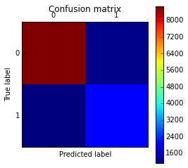

```
------------------------
Cross-validation Results
------------------------
Entropy based Model:
Score by fold: [ 0.81790281  0.81883316  0.80552712  0.80706244  0.80501535  0.81669227
  0.80440348  0.79569892  0.82693292  0.80440348]
Accuracy: 0.8102 (+/- 0.02)



Gini based Model:
Score by fold: [ 0.82046036  0.80348004  0.80501535  0.80143296  0.79989765  0.81464414
  0.80593958  0.80593958  0.8156682   0.80798771]
Accuracy: 0.8080 (+/- 0.01)
```

```python
from sklearn import cross_validation
from sklearn.cross_validation import train_test_split
from sklearn.metrics import confusion_matrix
from sklearn.metrics import accuracy_score

#--------------------------------------------
# Hold-out Test Set + Confusion Matrix
#--------------------------------------------
print("-------------------------------------------------")
print("Accuracy and Confusion Matrix on Hold-out Testset")
print("-------------------------------------------------")
#define a decision tree model using entropy based information gain
decTreeModel2 = tree.DecisionTreeClassifier(criterion='entropy')
#Split the data: 60% training : 40% test set
instances_train, instances_test, target_train, target_test = cross_validation.train_test_split(train_dfs, targetLabels, test_size=0.4, random_state=0)
#fit the model using just the test set
decTreeModel2.fit(instances_train, target_train)
#Use the model to make predictions for the test set queries
predictions = decTreeModel2.predict(instances_test)
#Output the accuracy score of the model on the test set
print("Accuracy= " + str(accuracy_score(target_test, predictions, normalize=True)))
#Output the confusion matrix on the test set
confusionMatrix = confusion_matrix(target_test, predictions)
print(confusionMatrix)
print("\n\n")

#Draw the confusion matrix
import matplotlib.pyplot as plt
%matplotlib inline
# Show confusion matrix in a separate window
plt.matshow(confusionMatrix)
#plt.plot(confusionMatrix)
plt.title('Confusion matrix')
plt.colorbar()
plt.ylabel('True label')
plt.xlabel('Predicted label')
plt.show()

#--------------------------------------------
# Cross-validation to Compare to Models
#--------------------------------------------
print("------------------------")
print("Cross-validation Results")
print("------------------------")

#run a 10 fold cross validation on this model using the full census data
scores=cross_validation.cross_val_score(decTreeModel2, instances_train, target_train, cv=10)
#the cross validaton function returns an accuracy score for each fold
print("Entropy based Model:")
print("Score by fold: " + str(scores))
#we can output the mean accuracy score and standard deviation as follows:
print("Accuracy: %0.4f (+/- %0.2f)" % (scores.mean(), scores.std() * 2))
print("\n\n")

#for a comparison we will do the same experiment using a decision tree that uses the Gini impurity metric
decTreeModel3 = tree.DecisionTreeClassifier(criterion='gini')
scores=cross_validation.cross_val_score(decTreeModel3, instances_train, target_train, cv=10)
print("Gini based Model:")
print("Score by fold: " + str(scores))
print("Accuracy: %0.4f (+/- %0.2f)" % (scores.mean(), scores.std() * 2))
```